# Assignment 2

Briana Flynn

9/22/2020

# Instructions

Select a large area and create a map of the area, with its associated subareas, using each of three different map projections. Indicate the map projection you’ve used for each. Identify a variable and use at least three different methods to show how it varies among the subareas.

# Loading Data & Identifying Area of Interest

I began by loading a number of libraries and new packages. After loading a world map to R for the first time, I chose South America as the large area I would re-project, transform, and collect data for in this assignment.

```r
library(ggplot2)
library(sf)
library(rnaturalearth)
library(tidyverse)
library(ggspatial)
library(cartogram)
library(ggthemes)
library(rgdal)
library(grid)
```

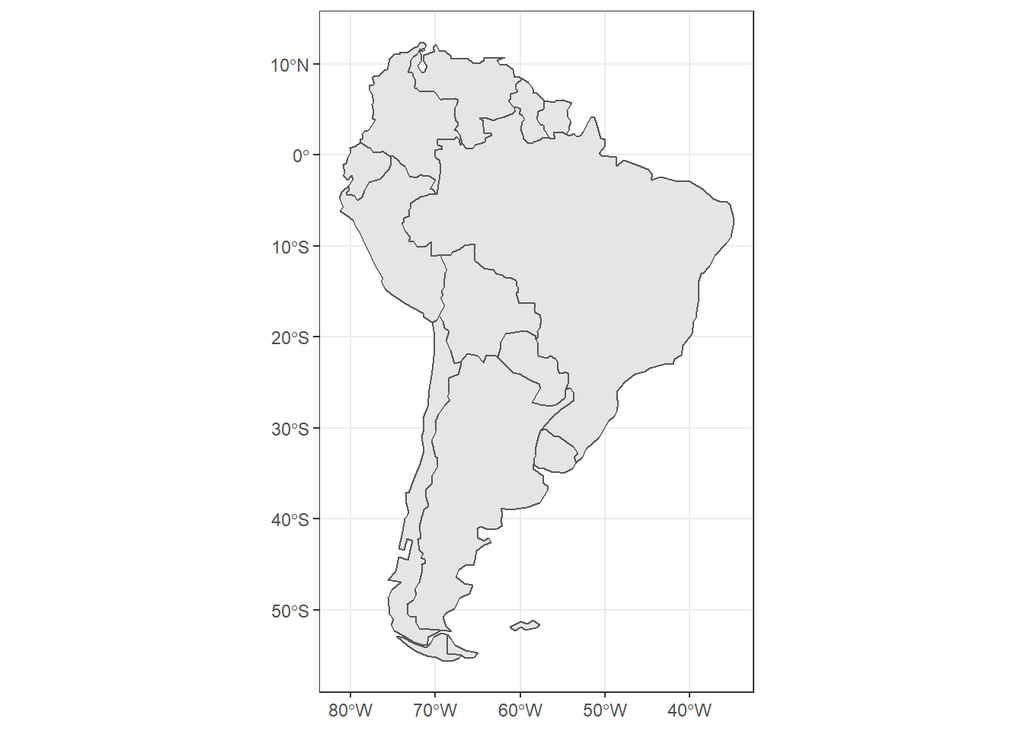

```r
sacountries <- ne_countries(continent = "South America", returnclass = "sf")

sa_map <-ggplot (sacountries) +
  geom_sf() +
  theme_bw()

sa_map
```

# Representing South America Using Alternate Map Projections

With South America as my chosen “large area” for Assignment 2, I looked for interesting and/or suitable map projections by searching for standard and then South America-focused projection systems. I settled on three projections:

```r
ROBINSON <- "+proj=robin +lon_0=0 +x_0=0 +y_0=0 +ellps=WGS84 +datum=WGS84 +units=m +no_defs"
ALBERS <- "+proj=lcc +lat_1=-5 +lat_2=-42 +lat_0=-32 +lon_0=-60 +x_0=0 +y_0=0 +ellps=aust_SA +units=m +no_defs"
CEA <- "+proj=cea +lon_0=-60 +lat_ts=-5 +x_0=0 +y_0=0 +ellps=WGS84 +units=m +no_defs"
```

## Robinson Projection

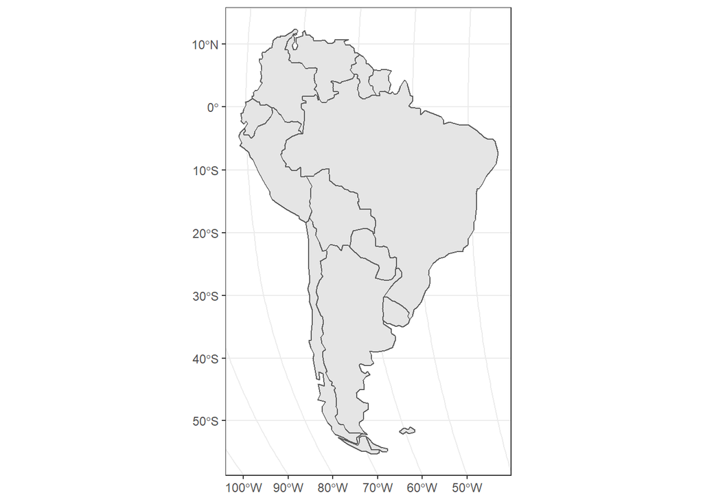

```r
ggplot(sacountries) +
  geom_sf() +
  coord_sf(crs = ROBINSON) +
  theme_bw()
```

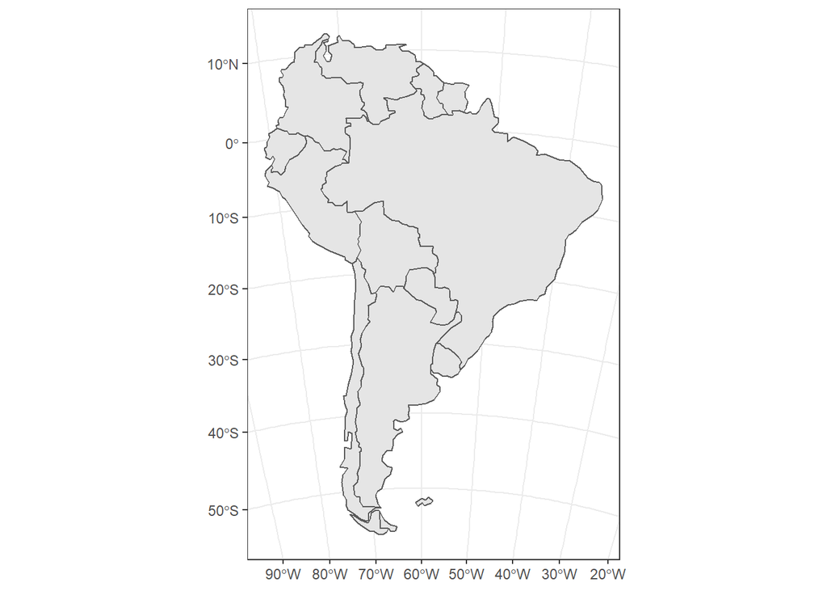

```r
ggplot(sacountries) +
  geom_sf() +
  coord_sf(crs = ALBERS) +
  theme_bw()
```

## Cylndrical Equal Area Projection

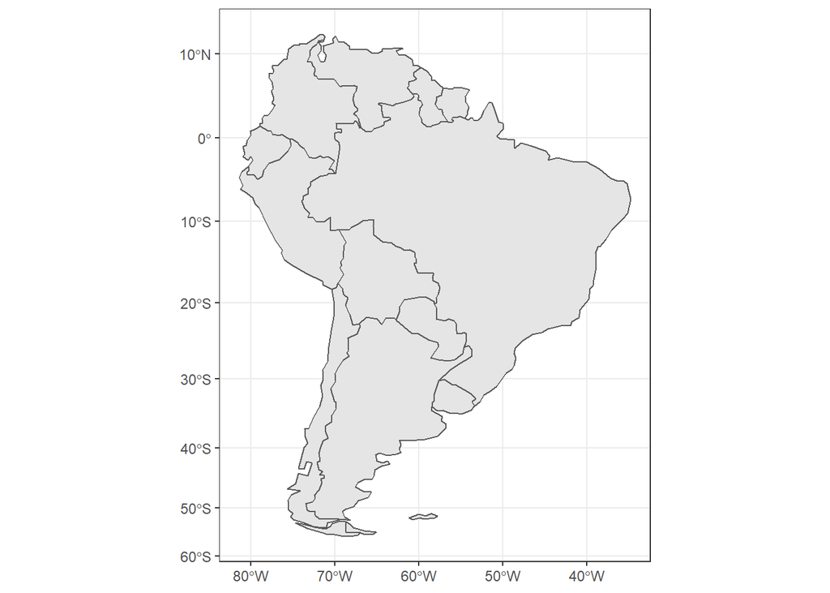

```r
ggplot(sacountries) +
  geom_sf() +
  coord_sf(crs = CEA) +
  theme_bw()
```